# GF-0604 Procesamiento de datos geográficos Laboratorio 02: R - Graficación básica

Aaron Blanco

2020-04-20

## Descripción general

En este laboratorio, aplicará varios comandos de graficación en el lenguaje [R](https://www.r-project.org/). Además, aprenderá a bifurcar y clonar repositorios del protocolo [Git](https://git-scm.com/) en la plataforma [GitHub](https://github.com/), para editarlos en su estación de trabajo mediante [RStudio](https://rstudio.com/). El resultado final será un documento en la sintaxis [R Markdown](https://rmarkdown.rstudio.com/) publicado en [GitHub Pages](https://pages.github.com/).

## Fecha de entrega y entregables

La fecha límite de entrega de este laboratorio es el **30 de abril de 2020**. Debe enviarle al profesor por correo electrónico la dirección del sitio en GitHub Pages resultante (ej. https://usuario.github.io/laboratorio-02-r-graficacion-basica/).

## Objetivos

1. Aprender a bifurcar un repositorio en GitHub.
2. Aprender a clonar un repositorio mediante el protocolo Git y la interfaz de RStudio.
3. Aprender a editar un documento en R Markdown, incluyendo código en el lenguaje R.
4. Aplicar comandos de graficación de R.

## Trabajo previo

Se recomienda leer el material preparado por el profesor y consultar los recursos listados en [Lección 04: El lenguaje de programación R - Introducción](https://geoprocesamiento-2020i.github.io/leccion-04-r-introduccion/).

## Bifuración y clonación de este documento

Ejecute los siguientes pasos para bifurcar a su cuenta en GitHub el repositorio que contiene este documento y posteriormente clonarlo a su computadora para editarlo con RStudio:

1. Bifurque (*fork*) el repositorio https://github.com/geoprocesamiento-2020i/laboratorio-02-r-graficacion a su cuenta personal en GitHub.
2. En el apartado *Settings* del repositorio bifurcado a su cuenta, busque la sección *GitHub Pages* y habilítela al seleccionar *master branch* como fuente. Tome nota de la dirección web resultante (ej. https://usuario.github.io/laboratorio-02-r-graficacion-basica/).
3. En RStudio, clone el repositorio de su cuenta personal con la opción de menú *File - New Project - Version Control - Git*. En *Repository URL* escriba la dirección de su repositorio (ej. https://github.com/usuario/laboratorio-02-r-graficacion-basica.git). Puede obtener esta dirección con el botón *Clone or download*, en la página principal del mismo repositorio.
4. Modifique el documento en R Studio.
5. Cada vez que desee actualizar su documento en GitHub y GitHub Pages:
- Presione el botón *Knit* en RStudio para generar el documento correspondiente en la sintaxis HTML.
- Suba a su repositorio en GitHub, los archivos *index.Rmd* e *index.html*.

## Desarrollo

1. (10%) Mediante la función `read.csv()`, cargue en un data frame el archivo CSV con datos de casos de Covid-19 ubicado en https://raw.githubusercontent.com/geoprocesamiento-2020i/datos/master/covid19/casos/ca/ca-covid19.csv. Luego, despliéguelo mediante la función `print()`.

```r
# Importación de datos de casos recuperados, fallecidos, activos y confirmados de Covid-19 en los países de Centroamérica
ca_covid19 <- read.csv(file='https://raw.githubusercontent.com/geoprocesamiento-2020i/datos/master/covid19/casos/ca/ca-covid19.csv')

# Despliegue de los datos
print(ca_covid19)
```

```
##   pais recuperados fallecidos activos confirmados
## 1  BLZ           0          2      16          18
## 2  CRI          67          4     555         626
## 3  GTM          19          5     172         196
## 4  HND           9         35     382         426
## 5  NIC           5          1       3           9
## 6  PAN          75        103    3573        3751
## 7  SLV          30          6     123         159
## 8  DOM         208        189    3217        3614
```

2. (10%) Genere un resumen de los datos con la función `summary()`.

```r
print(summary(ca_covid19))
```

```
##       pais    recuperados       fallecidos        activos
##  BLZ    :1   Min.   :  0.00   Min.   :  1.00   Min.   :   3.00
##  CRI    :1   1st Qu.:  8.00   1st Qu.:  3.50   1st Qu.:  96.25
##  DOM    :1   Median : 24.50   Median :  5.50   Median : 277.00
##  GTM    :1   Mean   : 51.62   Mean   : 43.12   Mean   :1005.12
##  HND    :1   3rd Qu.: 69.00   3rd Qu.: 52.00   3rd Qu.:1220.50
##  NIC    :1   Max.   :208.00   Max.   :189.00   Max.   :3573.00
##  (Other):2
##   confirmados
##  Min.   :   9.0
##  1st Qu.: 123.8
##  Median : 311.0
##  Mean   :1099.9
##  3rd Qu.:1373.0
##  Max.   :3751.0
##
```

3. (10%) Con la función `barplot()`, genere un gráfico de barras de los casos confirmados.

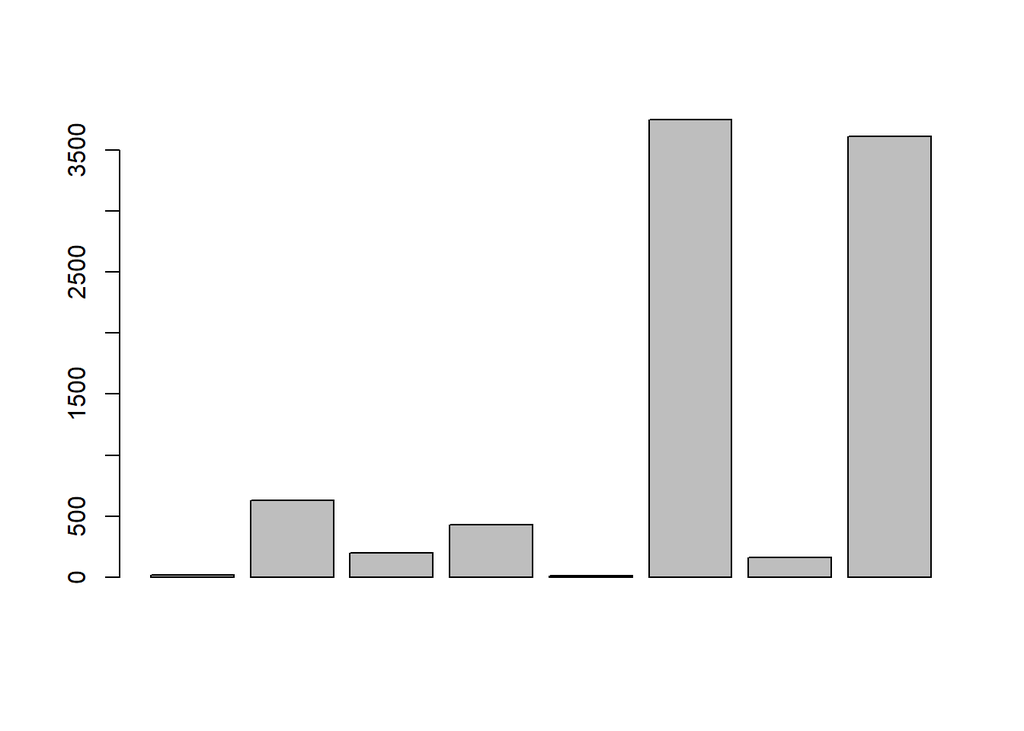

```r
barplot(height=ca_covid19$confirmados)
```

4. (10%) Con la función `order()`, ordene el data frame por cantidad de casos confirmados y genere de nuevo el gráfico.

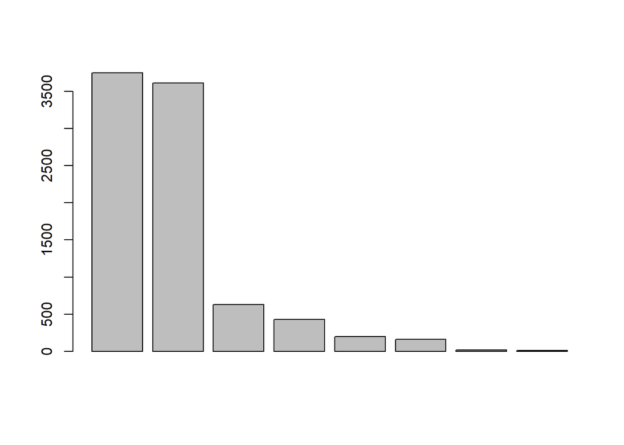

```r
confirmados.ordenado <- order(ca_covid19$confirmados, decreasing=TRUE)
ca_covid19.confirmados <- ca_covid19[confirmados.ordenado,]
barplot(height=ca_covid19.confirmados$confirmados)
```

5. (10%) Incluya en el gráfico los siguientes componentes:
- Nombres de los países en el eje correspondiente.
- Etiquetas en ambos ejes (x, y).
- Titulo del gráfico.

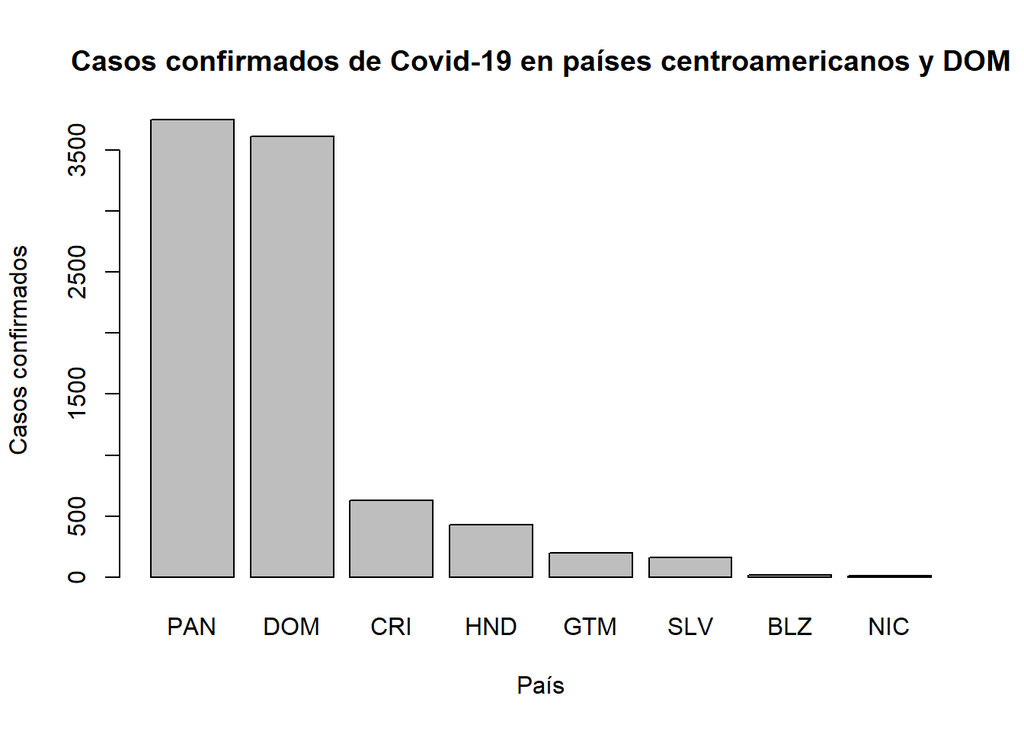

```r
barplot(height=ca_covid19.confirmados$confirmados, names.arg=ca_covid19.confirmados$pais, xlab="País", ylab="Casos confirmados", main="Casos confirmados de Covid-19 en países centroamericanos y DOM")
```

6. Genere gráficos similares al del paso anterior para:

**(todos los pasos incluidos)**

- (25%) Casos activos.

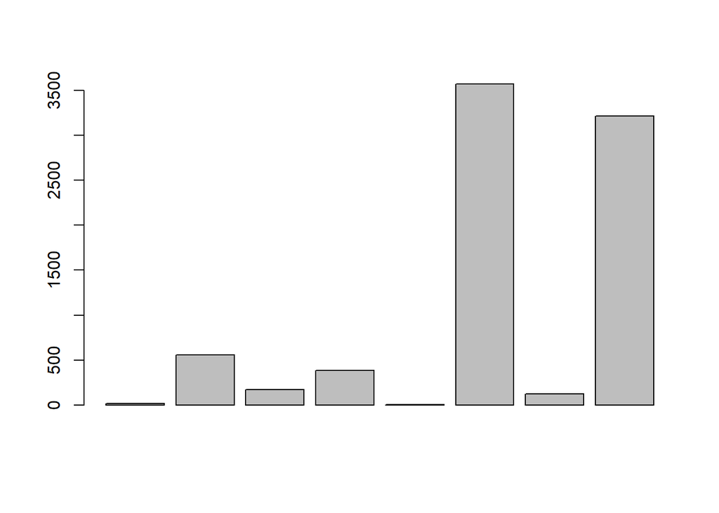

```r
barplot(height=ca_covid19$activos)
```

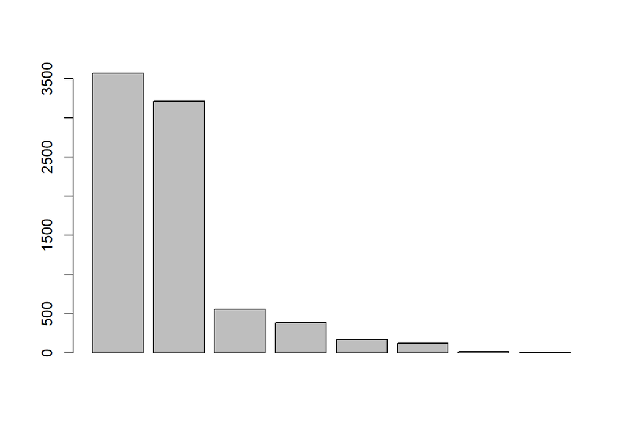

```r
activos.ordenado <- order(ca_covid19$activos, decreasing=TRUE)
ca_covid19.activos <- ca_covid19[activos.ordenado,]
barplot(height=ca_covid19.activos$activos)
```

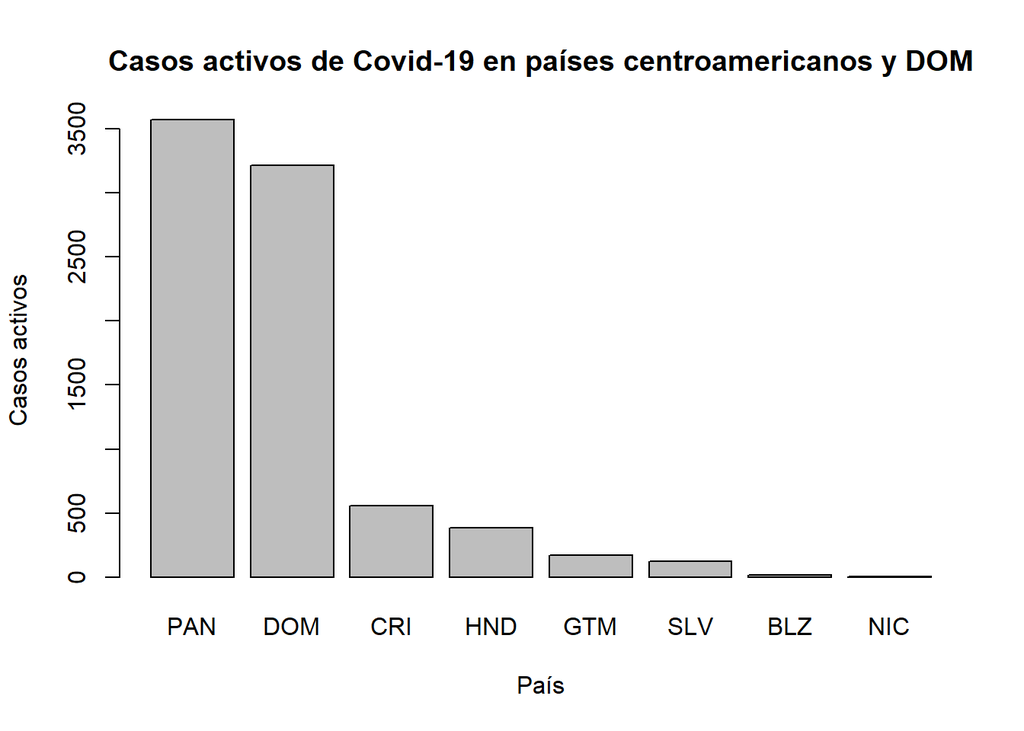

```r
barplot(height=ca_covid19.activos$activos, names.arg=ca_covid19.confirmados$pais, xlab="País", ylab="Casos activos", main="Casos activos de Covid-19 en países centroamericanos y DOM")
```

- (25%) Casos fallecidos.

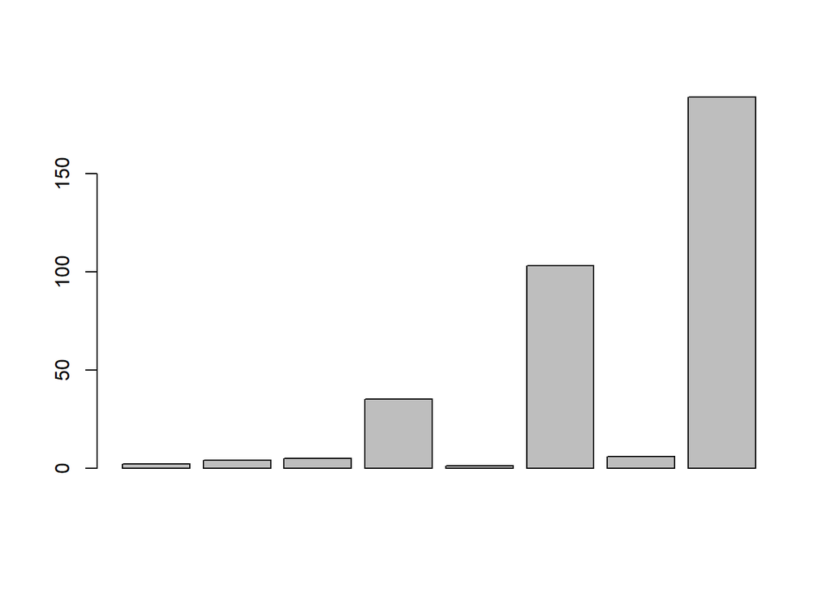

```r
barplot(height=ca_covid19$fallecidos)
```

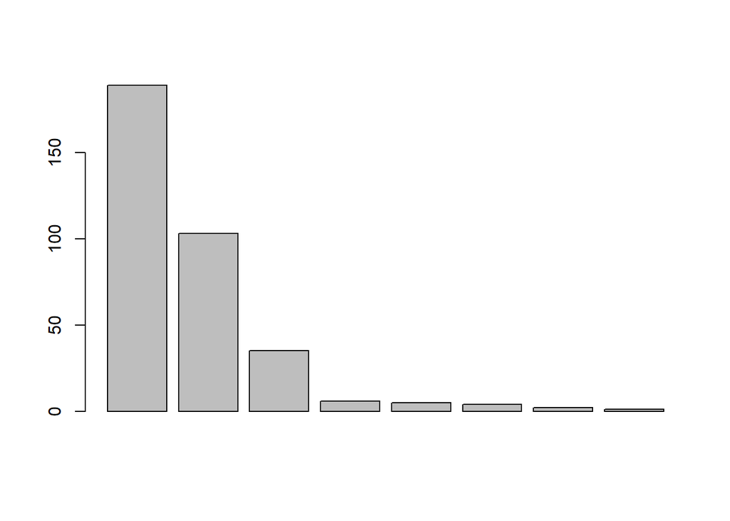

```r
fallecidos.ordenado <- order(ca_covid19$fallecidos, decreasing=TRUE)
ca_covid19.fallecidos <- ca_covid19[fallecidos.ordenado,]
barplot(height=ca_covid19.fallecidos$fallecidos)
```

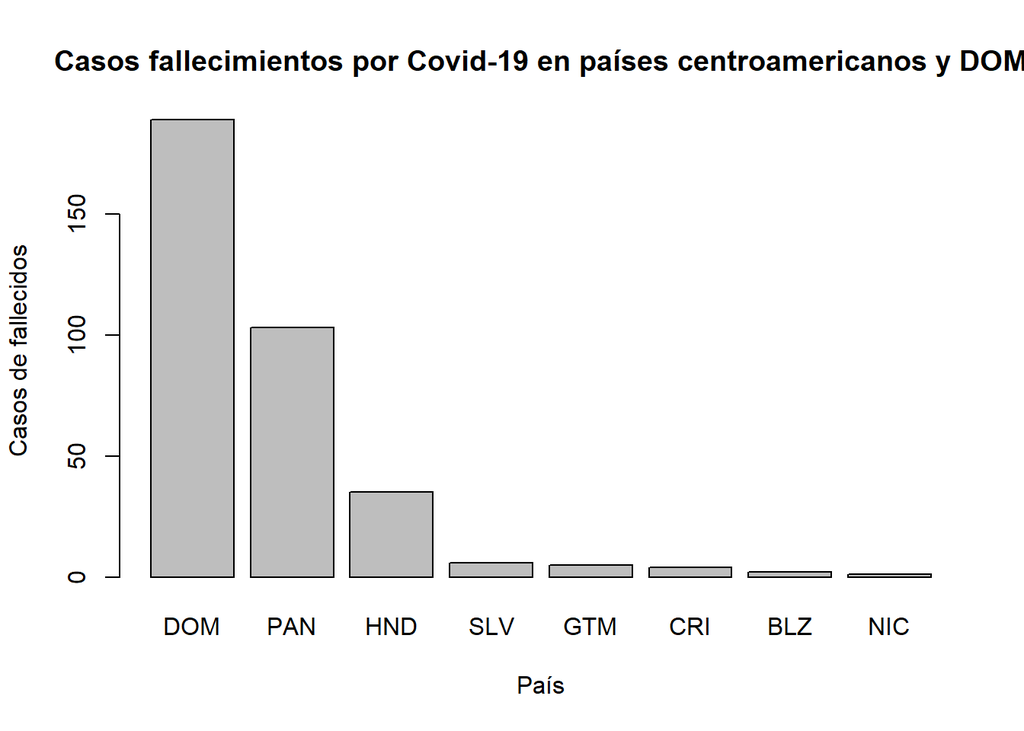

```r
barplot(height=ca_covid19.fallecidos$fallecidos, names.arg=ca_covid19.fallecidos$pais, xlab="País", ylab="Casos de fallecidos", main="Casos fallecimientos por Covid-19 en países centroamericanos y DOM")
```